# Data_Models_Yunyang

Yunyang Zhong

11/30/2021

# Lasso Model

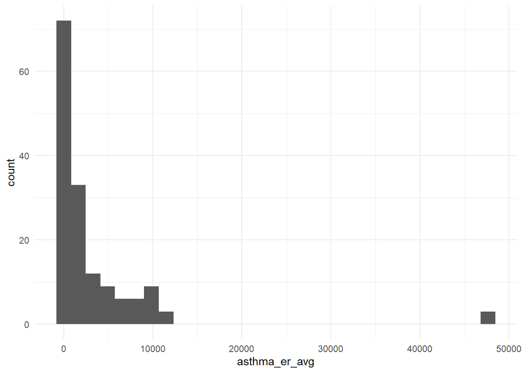

```
## # A tibble: 114 x 33
##    annual_mean_pm25 annual_mean_ozone annual_mean_pb annual_mean_pm10
##               <dbl>             <dbl>          <dbl>            <dbl>
##  1           0.769             1.91           -0.438           1.20
##  2          -0.791            -0.0862         -0.176          -0.426
##  3           0.0376           -0.153          -0.176           0.136
##  4           0.130            -0.118          -0.176           0.0213
##  5          -0.851             0.0999         -0.969          -0.949
##  6          -0.625            -0.107          -0.860          -0.442
##  7           0.861            -0.0905         -0.176          -0.150
##  8           1.70              0.645          -0.176          -1.08
##  9          -1.25             -1.03           -0.176          -0.150
## 10           3.09             -0.0905         -0.176          -0.150
## # ... with 104 more rows, and 29 more variables: annual_mean_co <dbl>,
## #   annual_mean_no2 <dbl>, annual_mean_so2 <dbl>, hpi2score <dbl>,
## #   economic <dbl>, education <dbl>, housing <dbl>, healthcareaccess <dbl>,
## #   neighborhood <dbl>, pollution <dbl>, transportation <dbl>, social <dbl>,
## #   insured <dbl>, uncrowded <dbl>, homeownership <dbl>, automobile <dbl>,
## #   commute <dbl>, inpreschool <dbl>, inhighschool <dbl>, bachelorsed <dbl>,
## #   employed <dbl>, abovepoverty <dbl>, income <dbl>, tree_canopy <dbl>, ...
```

```
## # A tibble: 20 x 1
##     penalty
##       <dbl>
##  1 1   e-10
##  2 3.36e-10
##  3 1.13e- 9
##  4 3.79e- 9
##  5 1.27e- 8
##  6 4.28e- 8
##  7 1.44e- 7
##  8 4.83e- 7
##  9 1.62e- 6
## 10 5.46e- 6
## 11 1.83e- 5
## 12 6.16e- 5
## 13 2.07e- 4
## 14 6.95e- 4
## 15 2.34e- 3
## 16 7.85e- 3
## 17 2.64e- 2
## 18 8.86e- 2
## 19 2.98e- 1
## 20 1   e+ 0
```

```
## # Tuning results
## # 5-fold cross-validation
## # A tibble: 5 x 5
##   splits          id    .metrics          .notes           .predictions
##   <list>          <chr> <list>            <list>           <list>
## 1 <split [91/23]> Fold1 <tibble [40 x 5]> <tibble [1 x 1]> <tibble [460 x 5]>
## 2 <split [91/23]> Fold2 <tibble [40 x 5]> <tibble [1 x 1]> <tibble [460 x 5]>
## 3 <split [91/23]> Fold3 <tibble [40 x 5]> <tibble [1 x 1]> <tibble [460 x 5]>
## 4 <split [91/23]> Fold4 <tibble [40 x 5]> <tibble [1 x 1]> <tibble [460 x 5]>
## 5 <split [92/22]> Fold5 <tibble [40 x 5]> <tibble [1 x 1]> <tibble [440 x 5]>
```

```
## # A tibble: 100 x 6
##    id     penalty .metric .estimator .estimate .config
##    <chr>    <dbl> <chr>   <chr>          <dbl> <chr>
##  1 Fold1 1   e-10 rmse    standard       0.232 Preprocessor1_Model01
##  2 Fold1 3.36e-10 rmse    standard       0.232 Preprocessor1_Model02
##  3 Fold1 1.13e- 9 rmse    standard       0.232 Preprocessor1_Model03
##  4 Fold1 3.79e- 9 rmse    standard       0.232 Preprocessor1_Model04
##  5 Fold1 1.27e- 8 rmse    standard       0.232 Preprocessor1_Model05
##  6 Fold1 4.28e- 8 rmse    standard       0.232 Preprocessor1_Model06
##  7 Fold1 1.44e- 7 rmse    standard       0.232 Preprocessor1_Model07
##  8 Fold1 4.83e- 7 rmse    standard       0.232 Preprocessor1_Model08
##  9 Fold1 1.62e- 6 rmse    standard       0.232 Preprocessor1_Model09
## 10 Fold1 5.46e- 6 rmse    standard       0.232 Preprocessor1_Model10
## # ... with 90 more rows
```

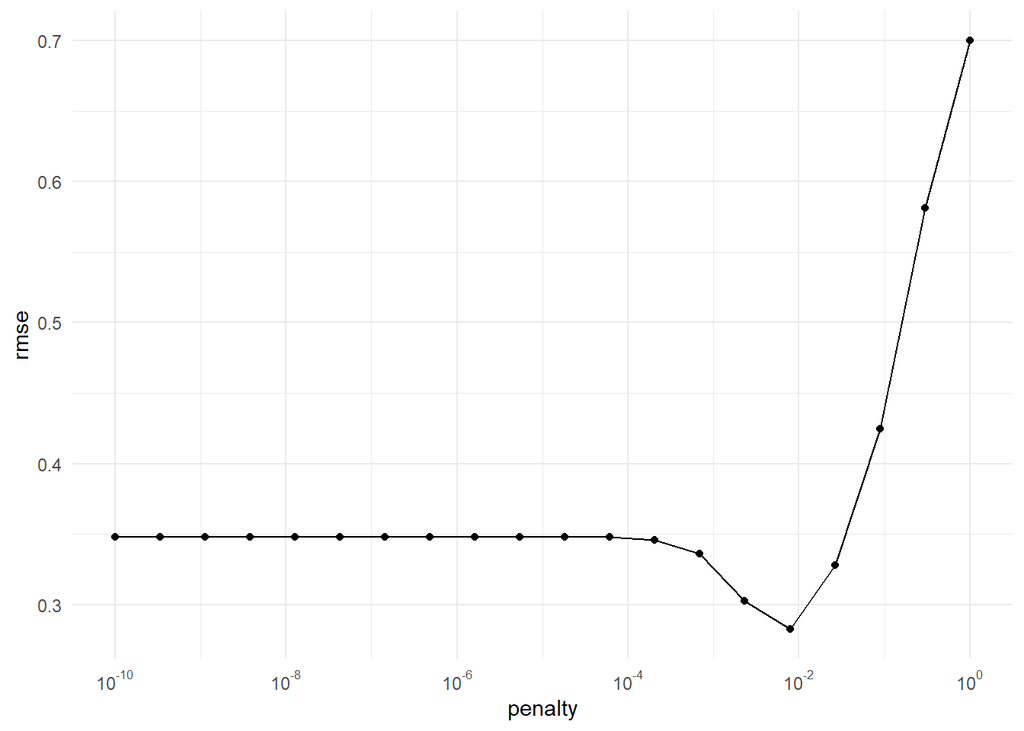

```
## # A tibble: 5 x 7
##    penalty .metric .estimator  mean     n std_err .config
##      <dbl> <chr>   <chr>      <dbl> <int>   <dbl> <chr>
## 1 0.00785  rmse    standard   0.282     5  0.0127 Preprocessor1_Model16
## 2 0.00234  rmse    standard   0.302     5  0.0147 Preprocessor1_Model15
## 3 0.0264   rmse    standard   0.328     5  0.0154 Preprocessor1_Model17
## 4 0.000695 rmse    standard   0.336     5  0.0344 Preprocessor1_Model14
## 5 0.000207 rmse    standard   0.346     5  0.0440 Preprocessor1_Model13
```

```
## # A tibble: 1 x 2
##   penalty .config
##     <dbl> <chr>
## 1 0.00785 Preprocessor1_Model16
```

```
## # A tibble: 1 x 9
##   penalty .metric .estimator  mean     n std_err .config            .best .bound
##     <dbl> <chr>   <chr>      <dbl> <int>   <dbl> <chr>              <dbl>  <dbl>
## 1 0.00785 rmse    standard   0.282     5  0.0127 Preprocessor1_Mod~ 0.282  0.295
```

```
## == Workflow ====================================================================
## Preprocessor: Recipe
## Model: linear_reg()
##
## -- Preprocessor ----------------------------------------------------------------
## 3 Recipe Steps
##
## * step_rm()
## * step_normalize()
## * step_dummy()
##
## -- Model -----------------------------------------------------------------------
## Linear Regression Model Specification (regression)
##
## Main Arguments:
##   penalty = 0.00784759970351461
##   mixture = 1
##
## Computational engine: glmnet
```

```
## # A tibble: 33 x 3
##    term              estimate penalty
##    <chr>                <dbl>   <dbl>
##  1 (Intercept)        2.97    0.00785
##  2 annual_mean_pm25   0       0.00785
##  3 annual_mean_ozone  0.00160 0.00785
##  4 annual_mean_pb     0.0210  0.00785
##  5 annual_mean_pm10  -0.161   0.00785
##  6 annual_mean_co     0.0539  0.00785
##  7 annual_mean_no2   -0.132   0.00785
##  8 annual_mean_so2    0.0652  0.00785
##  9 hpi2score          0       0.00785
## 10 economic           0       0.00785
## # ... with 23 more rows
```

```
## # A tibble: 2 x 4
##   .metric .estimator .estimate .config
##   <chr>   <chr>          <dbl> <chr>
## 1 rmse    standard       0.267 Preprocessor1_Model1
## 2 rsq     standard       0.846 Preprocessor1_Model1
```

# Xgboost model

First we used the use_xgboost() function, which gives recommendation on how to build our recipe, workflow, etc.

```
## xgboost_recipe <-
##   recipe(formula = log_asthma ~ ., data = pollution_training) %>%
##   step_novel(all_nominal(), -all_outcomes()) %>%
##   step_dummy(all_nominal(), -all_outcomes(), one_hot = TRUE) %>%
##   step_zv(all_predictors())
##
## xgboost_spec <-
##   boost_tree(trees = tune(), min_n = tune(), tree_depth = tune(), learn_rate = tune(),
##     loss_reduction = tune(), sample_size = tune()) %>%
##   set_mode("regression") %>%
##   set_engine("xgboost")
##
## xgboost_workflow <-
##   workflow() %>%
##   add_recipe(xgboost_recipe) %>%
##   add_model(xgboost_spec)
##
## set.seed(90624)
## xgboost_tune <-
##   tune_grid(xgboost_workflow, resamples = stop("add your rsample object"), grid = stop("add number of candidate points"))
```

Based on output from the use_xgboost() function and our previous recipes, we created our own recipe.

Next, we specified the model. learn_rate is the parameter we decided to tune, and we created a grid of 10 values to try in tuning for learn_rate as the following:

```
## # A tibble: 10 x 1
##      learn_rate
##           <dbl>
##  1 0.0000000001
##  2 0.000000001
##  3 0.00000001
##  4 0.0000001
##  5 0.000001
##  6 0.00001
##  7 0.0001
##  8 0.001
##  9 0.01
## 10 0.1
```

We then put the recipe and model specification into a workflow.

The next step is to train these models. registerDoParallel() was used to speed up the process.

Here is a table summarizing the results. We can see that larger learning rates actually seem to do better.

```
## # A tibble: 20 x 7
##      learn_rate .metric .estimator     mean     n std_err .config
##           <dbl> <chr>   <chr>         <dbl> <int>   <dbl> <chr>
##  1 0.0000000001 rmse    standard     2.57       5  0.0333 Preprocessor1_Model01
##  2 0.0000000001 rsq     standard   NaN          0 NA      Preprocessor1_Model01
##  3 0.000000001  rmse    standard     2.57       5  0.0333 Preprocessor1_Model02
##  4 0.000000001  rsq     standard   NaN          0 NA      Preprocessor1_Model02
##  5 0.00000001   rmse    standard     2.57       5  0.0333 Preprocessor1_Model03
##  6 0.00000001   rsq     standard     0.0589     1 NA      Preprocessor1_Model03
##  7 0.0000001    rmse    standard     2.57       5  0.0333 Preprocessor1_Model04
##  8 0.0000001    rsq     standard     0.741      5  0.0486 Preprocessor1_Model04
##  9 0.000001     rmse    standard     2.57       5  0.0333 Preprocessor1_Model05
## 10 0.000001     rsq     standard     0.751      5  0.0511 Preprocessor1_Model05
## 11 0.00001      rmse    standard     2.55       5  0.0333 Preprocessor1_Model06
## 12 0.00001      rsq     standard     0.746      5  0.0603 Preprocessor1_Model06
## 13 0.0001       rmse    standard     2.34       5  0.0340 Preprocessor1_Model07
## 14 0.0001       rsq     standard     0.764      5  0.0594 Preprocessor1_Model07
## 15 0.001        rmse    standard     1.09       5  0.0382 Preprocessor1_Model08
## 16 0.001        rsq     standard     0.800      5  0.0569 Preprocessor1_Model08
## 17 0.01         rmse    standard     0.217      5  0.0187 Preprocessor1_Model09
## 18 0.01         rsq     standard     0.915      5  0.0377 Preprocessor1_Model09
## 19 0.1          rmse    standard     0.134      5  0.0130 Preprocessor1_Model10
## 20 0.1          rsq     standard     0.959      5  0.0155 Preprocessor1_Model10
```

We also plotted the rmse to visually support our conclusion above.

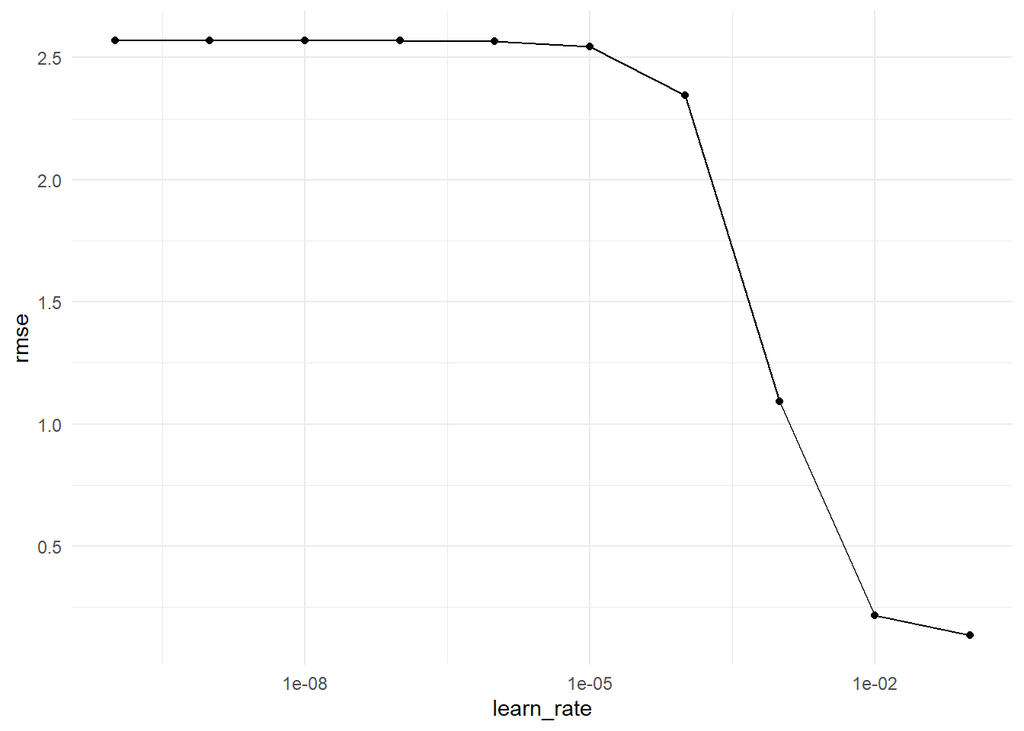

Then we decided to select the best learning rate parameter and finalize the model.

```
## # A tibble: 1 x 2
##   learn_rate .config
##        <dbl> <chr>
## 1        0.1 Preprocessor1_Model10
```

This graph tells us which predictors are the most important. It seems that supermarkets, annual_mean_no2, and homeownership have the largest influence on asthma ER visit.

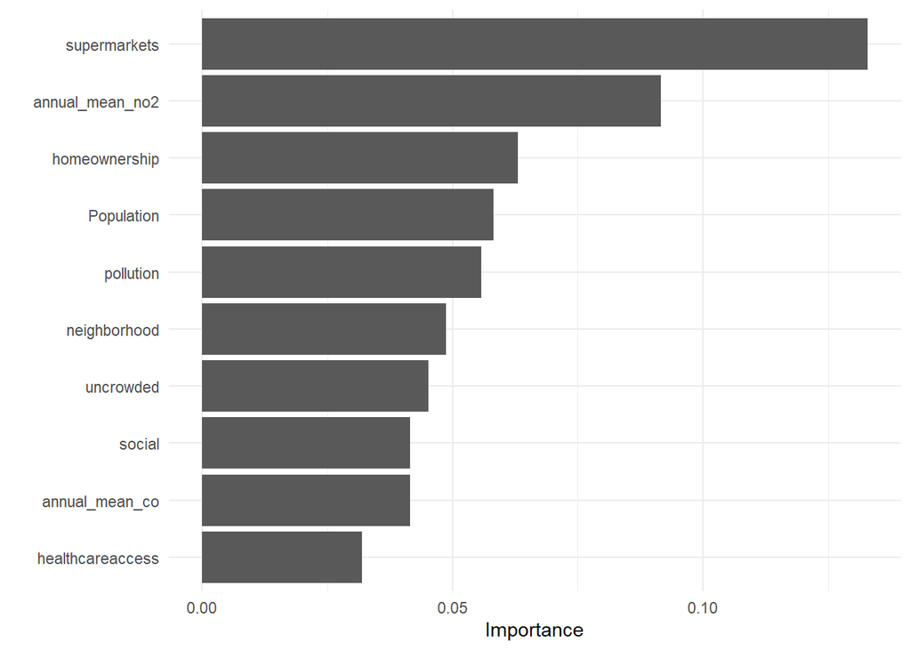

```
## [1] 0.05400519
```

The graph below visualized the results. We can conclude that the predicted values are very close to the actual values.

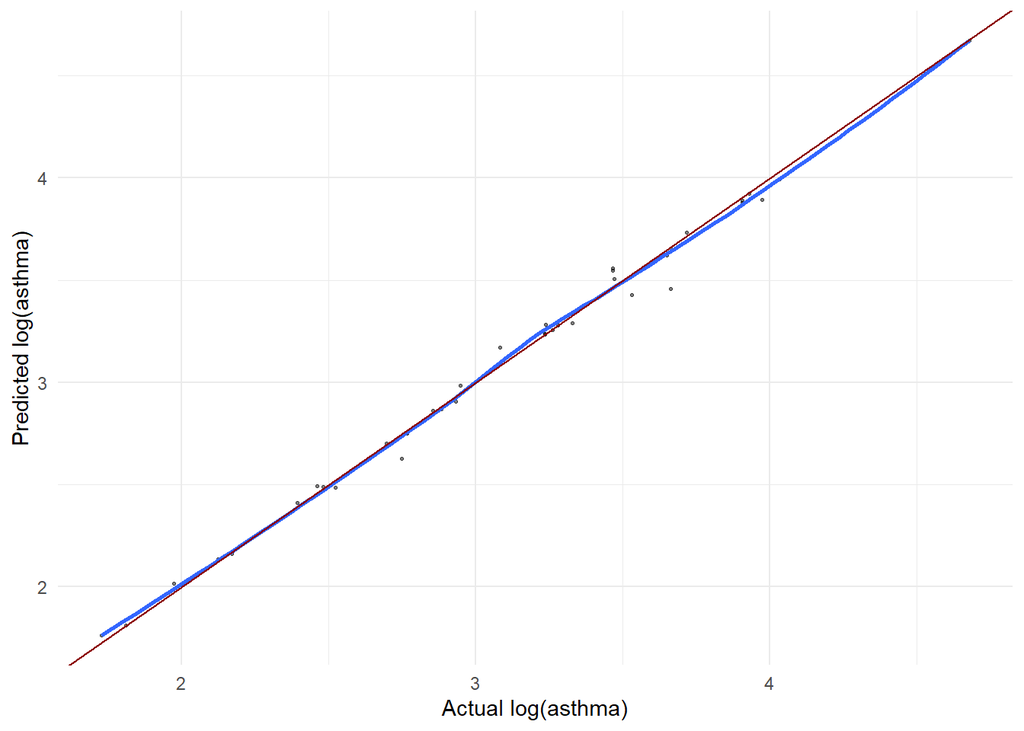

# Random Forest Model

```
## # A tibble: 114 x 33
##    annual_mean_pm25 annual_mean_ozone annual_mean_pb annual_mean_pm10
##               <dbl>             <dbl>          <dbl>            <dbl>
##  1           0.769             1.91           -0.438           1.20
##  2          -0.791            -0.0862         -0.176          -0.426
##  3           0.0376           -0.153          -0.176           0.136
##  4           0.130            -0.118          -0.176           0.0213
##  5          -0.851             0.0999         -0.969          -0.949
##  6          -0.625            -0.107          -0.860          -0.442
##  7           0.861            -0.0905         -0.176          -0.150
##  8           1.70              0.645          -0.176          -1.08
##  9          -1.25             -1.03           -0.176          -0.150
## 10           3.09             -0.0905         -0.176          -0.150
## # ... with 104 more rows, and 29 more variables: annual_mean_co <dbl>,
## #   annual_mean_no2 <dbl>, annual_mean_so2 <dbl>, hpi2score <dbl>,
## #   economic <dbl>, education <dbl>, housing <dbl>, healthcareaccess <dbl>,
## #   neighborhood <dbl>, pollution <dbl>, transportation <dbl>, social <dbl>,
## #   insured <dbl>, uncrowded <dbl>, homeownership <dbl>, automobile <dbl>,
## #   commute <dbl>, inpreschool <dbl>, inhighschool <dbl>, bachelorsed <dbl>,
## #   employed <dbl>, abovepoverty <dbl>, income <dbl>, tree_canopy <dbl>, ...
```

```
## # A tibble: 1 x 3
##    mtry min_n .config
##   <int> <int> <chr>
## 1    32     2 Preprocessor1_Model2
```

```
## [1] 0.008365557
```

```
## [1] 0.09146342
```

```
## # A tibble: 18 x 8
##     mtry min_n .metric .estimator  mean     n std_err .config
##    <int> <int> <chr>   <chr>      <dbl> <int>   <dbl> <chr>
##  1     1     2 rmse    standard   0.226     5 0.0162  Preprocessor1_Model1
##  2     1     2 rsq     standard   0.931     5 0.0279  Preprocessor1_Model1
##  3    32     2 rmse    standard   0.105     5 0.0123  Preprocessor1_Model2
##  4    32     2 rsq     standard   0.978     5 0.00647 Preprocessor1_Model2
##  5    63     2 rmse    standard   0.108     5 0.0122  Preprocessor1_Model3
##  6    63     2 rsq     standard   0.977     5 0.00654 Preprocessor1_Model3
##  7     1    21 rmse    standard   0.353     5 0.0290  Preprocessor1_Model4
##  8     1    21 rsq     standard   0.884     5 0.0276  Preprocessor1_Model4
##  9    32    21 rmse    standard   0.171     5 0.0159  Preprocessor1_Model5
## 10    32    21 rsq     standard   0.947     5 0.00910 Preprocessor1_Model5
## 11    63    21 rmse    standard   0.171     5 0.0165  Preprocessor1_Model6
## 12    63    21 rsq     standard   0.947     5 0.00792 Preprocessor1_Model6
## 13     1    40 rmse    standard   0.443     5 0.0339  Preprocessor1_Model7
## 14     1    40 rsq     standard   0.827     5 0.0397  Preprocessor1_Model7
## 15    32    40 rmse    standard   0.257     5 0.00911 Preprocessor1_Model8
## 16    32    40 rsq     standard   0.895     5 0.0106  Preprocessor1_Model8
## 17    63    40 rmse    standard   0.257     5 0.00700 Preprocessor1_Model9
## 18    63    40 rsq     standard   0.894     5 0.0104  Preprocessor1_Model9
```

# Stacking

After we had our set of candidate models (9 random forest, 20 lasso, and 10 boost), we started stacking. We followed the process laid out on the stacks webpage.

First, we created the stack. Shown by the number of columns, it removed some of the lasso models, likely since they were too similar to other lasso models. The set of candidate models now has 9 random forest, 9 lasso, and 9 boost.

We can look at the predictions from the candidate models in a tibble. Most of the predictions are very close to the actual values, except the first few boost models.

```
## # A tibble: 114 x 28
##    log_asthma boost_tune_1_01 boost_tune_1_03 boost_tune_1_04 boost_tune_1_05
##         <dbl>           <dbl>           <dbl>           <dbl>           <dbl>
##  1       3.65             0.5             0.5           0.500           0.503
##  2       2.06             0.5             0.5           0.500           0.502
##  3       2.06             0.5             0.5           0.500           0.502
##  4       2.82             0.5             0.5           0.500           0.502
##  5       3.05             0.5             0.5           0.500           0.502
##  6       3.98             0.5             0.5           0.500           0.503
##  7       1.95             0.5             0.5           0.500           0.502
##  8       2.29             0.5             0.5           0.500           0.502
##  9       2.17             0.5             0.5           0.500           0.502
## 10       1.73             0.5             0.5           0.500           0.502
## # ... with 104 more rows, and 23 more variables: boost_tune_1_06 <dbl>,
## #   boost_tune_1_07 <dbl>, boost_tune_1_08 <dbl>, boost_tune_1_09 <dbl>,
## #   boost_tune_1_10 <dbl>, pollution_lasso_tune_1_01 <dbl>,
## #   pollution_lasso_tune_1_13 <dbl>, pollution_lasso_tune_1_14 <dbl>,
## #   pollution_lasso_tune_1_15 <dbl>, pollution_lasso_tune_1_16 <dbl>,
## #   pollution_lasso_tune_1_17 <dbl>, pollution_lasso_tune_1_18 <dbl>,
## #   pollution_lasso_tune_1_19 <dbl>, pollution_lasso_tune_1_20 <dbl>, ...
```

We wanted to blend the predictions from each model together to form an even better overall prediction using the blend_predictions() function. Doing this with our models, we see only 4 models have non-zero coefficients, 1 random forest, 2 lasso, and 1 boost:

```
## # A tibble: 4 x 3
##   member                    type        weight
##   <chr>                     <chr>        <dbl>
## 1 pollution_rfTUNE_1_2      rand_forest 0.727
## 2 boost_tune_1_10           boost_tree  0.282
## 3 pollution_lasso_tune_1_18 linear_reg  0.0699
## 4 pollution_lasso_tune_1_19 linear_reg  0.0127
```

Here is the rmse for the various penalty parameters:

```
## # A tibble: 6 x 8
##    penalty mixture .metric .estimator  mean     n std_err .config
##      <dbl>   <dbl> <chr>   <chr>      <dbl> <int>   <dbl> <chr>
## 1 0.000001       1 rmse    standard   0.104    25 0.00232 Preprocessor1_Model1
## 2 0.00001        1 rmse    standard   0.104    25 0.00232 Preprocessor1_Model2
## 3 0.0001         1 rmse    standard   0.104    25 0.00232 Preprocessor1_Model3
## 4 0.001          1 rmse    standard   0.104    25 0.00234 Preprocessor1_Model4
## 5 0.01           1 rmse    standard   0.105    25 0.00260 Preprocessor1_Model5
## 6 0.1            1 rmse    standard   0.152    25 0.00470 Preprocessor1_Model6
```

We can examine some plots to see if we need to adjust the penalty parameter at all. This set of three plots with penalty on the x axis shows that we seem to have captured the smallest RMSE.

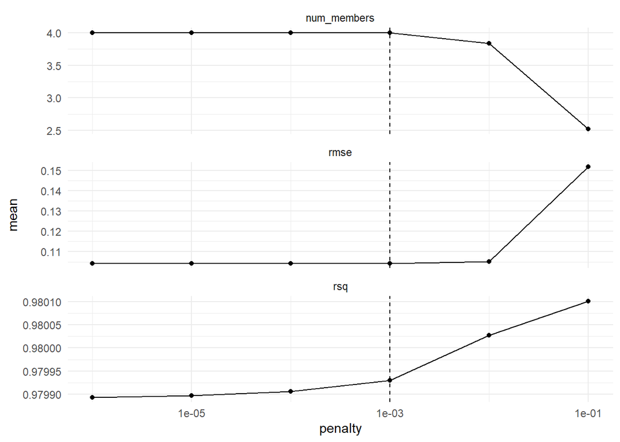

The blending weights for the top ensemble members are presented in this plot. The random forest has the highest weight, more than two times of the second highest weight boost has. The two lasso models have low weights.

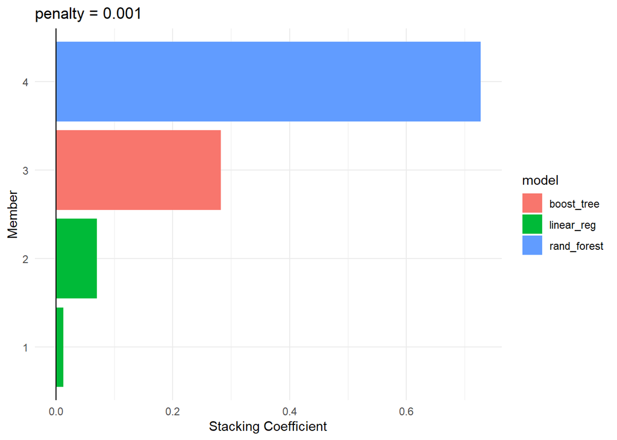

Finally we fit the candidate models with non-zero stacking coefficients to the full training data using fit_members() function. The numeric values of the blending weights for the top ensemble members are also printed out.

```
## # A tibble: 4 x 3
##   member                    type        weight
##   <chr>                     <chr>        <dbl>
## 1 pollution_rfTUNE_1_2      rand_forest 0.727
## 2 boost_tune_1_10           boost_tree  0.282
## 3 pollution_lasso_tune_1_18 linear_reg  0.0699
## 4 pollution_lasso_tune_1_19 linear_reg  0.0127
```

Here is a plot comparing predicted and actual values after fitting it to the testing data. We can see the two lines are almost the same!

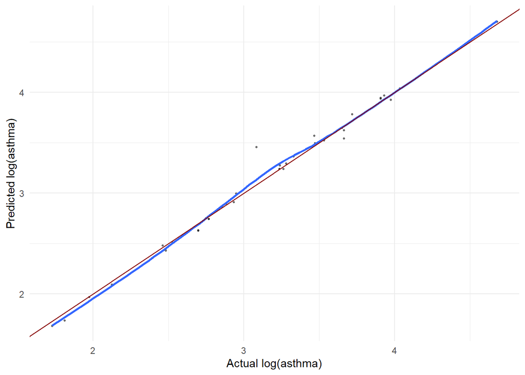

```
## [1] 0.07336316
```